# Assignment3

### Question 8

```r
# Get required libraries
library(class)
library("e1071")
library(randomForest)
library(tibble)

# source the partition function
fpart <- file.path("script", "partition_function.R")
source(fpart)

#################################################
#UTILITY FUNCTIONS USED IN THIS SCRIPT
#################################################

# Function to create a nested list
create_nested_list <- function(names, list_length){
  result <- lapply(names,
                   function(i){vector(mode = "list", length = list_length)})
  names(result) <- names
  return(result)
}
#################################################
# Set seed to produce constant results
set.seed(42)

# Perform stratified sampling
plabel_yeast <- partition(10, yeast_data$location)

# Add the fold information to the filtered Ecoli data
yeast_data_folds <- yeast_data %>%
  mutate(fold = plabel_yeast)

# Create lists to store the results of the CV
names_of_models <- c("KNN",'NaiveBayes','RF') # Names of the models used
list_of_prediction_scores <- create_nested_list(names_of_models, 10)  # list to store pred. scores

# 4-fold CV using stratified training and test sets
for(i in 1:10) {
  testset <- yeast_data_folds %>% filter(fold == i) %>% select(-fold, -SpAccNr)
  trainset <- yeast_data_folds %>% filter(fold != i) %>% select(-fold, -SpAccNr)

  #KNN
  knn_pred = knn(train = trainset[, -length(trainset)],
                  test = testset[, -length(trainset)],
                  cl = trainset[["location"]],
                  k = 21)
  correct_knn <- sum(knn_pred == as.character(testset[["location"]])) / dim(testset)[1]

  # Naive bayes
  nb <- naiveBayes(location ~ ., data = trainset)
  nb_pred <- predict(nb, testset)
  correct_nb <- sum(nb_pred == as.character(testset[["location"]])) / dim(testset)[1]

  # Random Forest
  rf <- randomForest(location ~ ., data = trainset)
  rf_pred <- as.factor(as.vector(predict(rf, testset)))
  correct_rf <- sum(rf_pred == as.character(testset[["location"]])) / dim(testset)[1]


  # Store the results
  list_of_prediction_scores[["KNN"]][[i]] <- correct_knn
  list_of_prediction_scores[["NaiveBayes"]][[i]] <- correct_nb
  list_of_prediction_scores[["RF"]][[i]] <- correct_rf
}

# Create the table of accuracies
list_of_accuracy_tables = create_nested_list(names_of_models, 1) # list to store models

for (method in names(list_of_prediction_scores)) {
  accuracy_tbl <- list_of_prediction_scores[[method]] %>%
    as.data.frame() %>%
    t() %>%
    as_tibble() %>%
    rownames_to_column(var = "Partition") %>%
    rename("Accuracy" = "V1")

  list_of_accuracy_tables[[method]] <- accuracy_tbl
}

# Create a table of all the partition (1-4) results
result_tbl <- data.frame(
  Partition = c(1:10),
  KNN = list_of_accuracy_tables[["KNN"]]$Accuracy,
  NaiveBayes = list_of_accuracy_tables[["NaiveBayes"]]$Accuracy,
  RF = list_of_accuracy_tables[["RF"]]$Accuracy
)

# Create the table of means & std. devs for each method
means <- data.frame("mean", mean(result_tbl$KNN), mean(result_tbl$NaiveBayes), mean(result_tbl$RF))
names(means) <- c("Partition", "KNN", "NaiveBayes", "RF")

std.devs <- data.frame("std.dev.", sd(result_tbl$KNN), sd(result_tbl$NaiveBayes), sd(result_tbl$RF))
names(std.devs) <- c("Partition", "KNN", "NaiveBayes", "RF")

result_tbl.mean <- rbind(result_tbl, means)
result_tbl.mean.sd <- rbind(result_tbl.mean, std.devs)

# Print the final output table
result_tbl.mean.sd %>%
  knitr::kable(format="html", caption="Table 5: Yeast data - Results of CV shown in accuracy, including the means and standard deviations") %>%
  kableExtra::kable_styling()
```

Table 5: Yeast data - Results of CV shown in accuracy, including the means and standard deviations

| Partition | KNN | NaiveBayes | RF |
| --- | --- | --- | --- |
| 1 | 0.6137931 | 0.5931034 | 0.5931034 |
| 2 | 0.5958904 | 0.5821918 | 0.6027397 |
| 3 | 0.6369863 | 0.6164384 | 0.6369863 |
| 4 | 0.5918367 | 0.5850340 | 0.6394558 |
| 5 | 0.5743243 | 0.5675676 | 0.5810811 |
| 6 | 0.5608108 | 0.5270270 | 0.6081081 |
| 7 | 0.6734694 | 0.5646259 | 0.6462585 |
| 8 | 0.5547945 | 0.5410959 | 0.5273973 |
| 9 | 0.5902778 | 0.5277778 | 0.5694444 |
| 10 | 0.5586207 | 0.5586207 | 0.6206897 |
| mean | 0.5950804 | 0.5663482 | 0.6025264 |
| std.dev. | 0.0377754 | 0.0289841 | 0.0366854 |

**Answer to Q8:**

- All models seem to perform quite similarly, although RF has the highest avg. accuracy of 0.60
- The std. deviation is also rather similar between the models but KNN has the highest std. dev
- The single best prediction accuracy was obtained by KNN at partition 7 (accuracy = 0.67)

### Question 9

```r
set.seed(42)
t.knn.nb <- t.test(result_tbl$KNN, result_tbl$NaiveBayes, paired = TRUE)
t.knn.rf <- t.test(result_tbl$KNN, result_tbl$RF, paired = TRUE)
t.nb.rf <- t.test(result_tbl$NaiveBayes, result_tbl$RF, paired = TRUE)

t.test.table <- data.frame(
  KNN = c(NA, t.knn.nb$p.value, t.knn.rf$p.value),
  NaiveBayes = c(t.knn.nb$p.value, NA, t.nb.rf$p.value),
  RF = c(t.knn.rf$p.value, t.nb.rf$p.value, NA)
)

rownames(t.test.table) <- c("KNN", "NaiveBayes", "RF")

# Print the table of t-tests
t.test.table %>% knitr::kable(format="html", caption="Table 6: T-tests for each method (Yeast data)") %>% kableExtra::kable_styling()
```

Table 6: T-tests for each method (Yeast data)

|  | KNN | NaiveBayes | RF |
| --- | --- | --- | --- |
| KNN | NA | 0.0231600 | 0.5029432 |
| NaiveBayes | 0.0231600 | NA | 0.0073101 |
| RF | 0.5029432 | 0.0073101 | NA |

**Answer to Q9:** :

- When looking at the p-values (and again using a cutoff of < 0.05), it seems that only Naive Bayes seems to produce results that are significantly different from RF and KNN. RF and KNN again produce very similar results so they are not significantly different from each other in terms of accuracy.

### Question 10

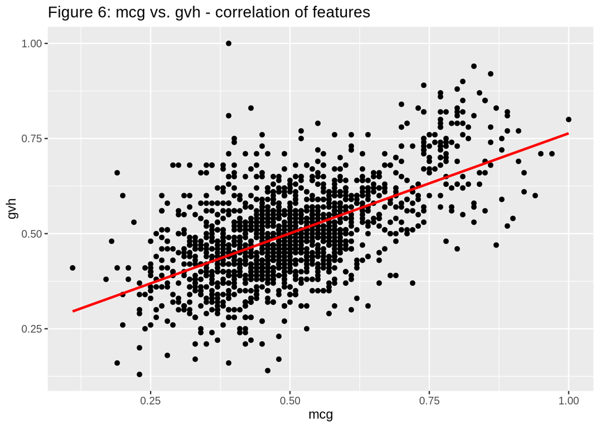

```r
library(tidyverse)
p <- ggplot(data = yeast_data,
            mapping = aes(x = mcg,
                          y = gvh)) +
  geom_point() +
  stat_smooth(method = lm, se = F, colour = 'red') +
  labs(title = "Figure 6: mcg vs. gvh - correlation of features", x = "mcg", y = "gvh")


print(p)
```

**Answer to Q10:** :

- Naive Bayes is called ‘naive’ because it makes the assumption that all the features have zero correlation with each other.
- In reality, As can be seen from the pairplot (in question 7), some features (i.e. mcg and gvh) are somewhat correlated. So all pairs of predictors aren’t really conditionally independent.
- The plot above (Figure 6) shows the linear relationship of mcg and gvh variables in the yeast data.

### Question 11

**Answer to Q11:**

- Probabilistic classification methods are able to produce a probability distribution over all possible class labels. For example Naive Bayes, decision trees, and random forests are able to produce this type of output.
- KNN, on the other hand, cannot handle the number of neighbours probabilistically and so it is not able to produce this kind of output.
- To produce a probability distribution over class labels for the NaiveBayes, the argument type = “raw” should be provided to the model
- To produce this for random forest, simply set the argument norm.votes = FALSE (= raw vote counts)